### #TidyTuesday 9-4-18 Week 23

This week’s data is fast food nutritional data. The data can be found [here](https://github.com/rfordatascience/tidytuesday/blob/master/data/2018-09-04/fastfood_calories.csv).

First, let’s load the tidyverse library & read in our data.

```r
library(tidyverse)

data <- read_csv("fastfood_calories.csv")
```

Today, we’re going to do a violin plot. In this case, the violin plot will show the distribution of calories for each item grouped by restaurant.

First, let’s use select() to get the columns we need. For this plot, all we need is the restaurant & the calories columns. We’ll use head() to take a peek at the data & make sure everything looks ok!

```r
data1 <- data %>%
  select(restaurant, calories)

head(data1)
```

```
## # A tibble: 6 x 2
##   restaurant calories
##   <chr>         <int>
## 1 Mcdonalds       380
## 2 Mcdonalds       840
## 3 Mcdonalds      1130
## 4 Mcdonalds       750
## 5 Mcdonalds       920
## 6 Mcdonalds       540
```

Let’s do the basic plot. Looking at the basic plot lets us make sure that we’re headed in the right direction.

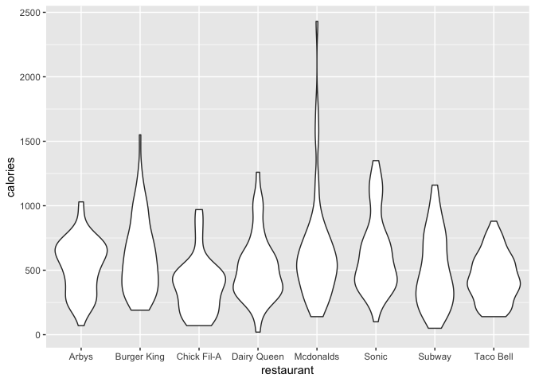

```r
ggplot(data1) +
  geom_violin(aes(restaurant, calories))
```

Looks good so far! Let’s add a little more information. We can add a point for each individual item. This helps us get a better understanding of our data. For that we add geom_jitter() using the same aes() call as before. More about geom_jitter [here](https://ggplot2.tidyverse.org/reference/geom_jitter.html).

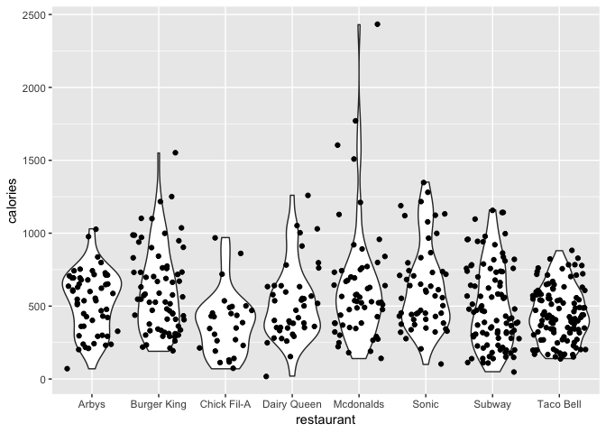

```r
ggplot(data1) +
  geom_violin(aes(restaurant, calories)) +
  geom_jitter(aes(restaurant, calories))
```

This helps but we can make those points look better. We can make the distribution tighter by adding a width argument to the geom_jitter() call. You might need to play with this a little bit to get the grouping the way you would like.

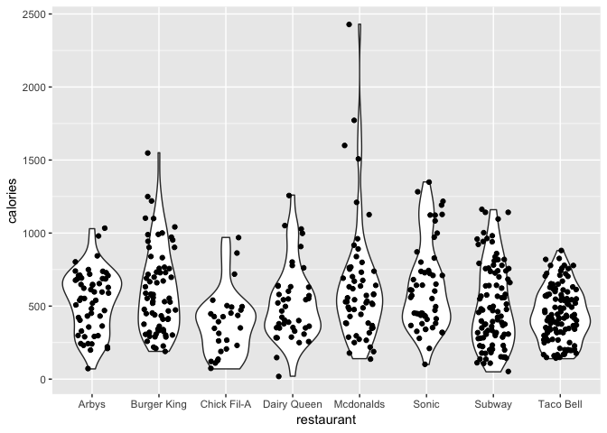

```r
ggplot(data1) +
  geom_violin(aes(restaurant, calories)) +
  geom_jitter(aes(restaurant, calories), width= 0.25)
```

Next, I would like to see these violin plots horizontally instead of vertically. For this we use coord_flip().

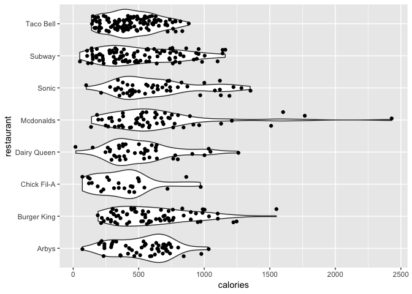

```r
ggplot(data1) +
  geom_violin(aes(restaurant, calories)) +
  geom_jitter(aes(restaurant, calories), width= 0.25) +
  coord_flip()
```

I like that better! Now let’s make it pretty. First, we’ll add some color. We add color to the aes call in both geom_violin() & geom_jitter(). Then we add scale_color_brewer() to pick our color palette.

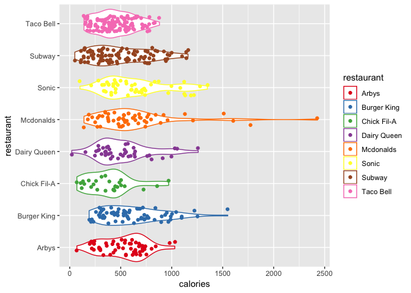

```r
ggplot(data1) +
  geom_violin(aes(restaurant, calories, color = restaurant)) +
  geom_jitter(aes(restaurant, calories, color = restaurant), width= 0.25) +
  coord_flip() +
  scale_color_brewer(palette="Set1")
```

Now let’s start cleaning it up. Let’s remove the legend. It’s not really helping us here. Also, I want to remove the axis titles & bump up the font size on the tick mark labels. All of this can be done in the theme() call.

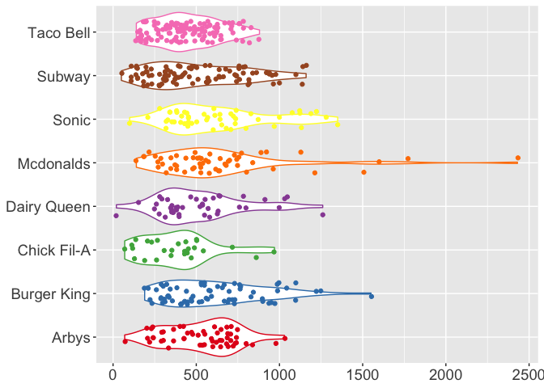

```r
ggplot(data1) +
  geom_violin(aes(restaurant, calories, color = restaurant)) +
  geom_jitter(aes(restaurant, calories, color = restaurant), width= 0.25) +
  coord_flip() +
  theme(legend.position = "none",
    axis.title = element_blank(),
    axis.text = element_text(size = 14)) +
  scale_color_brewer(palette="Set1")
```

Now that’s looking better. Next, I removed the backgound panel, grid lines & border. I also want to remove the tick marks on the y-axis. I made the x-axis grid lines gray & dashed. All these things can be changed in the theme() call.

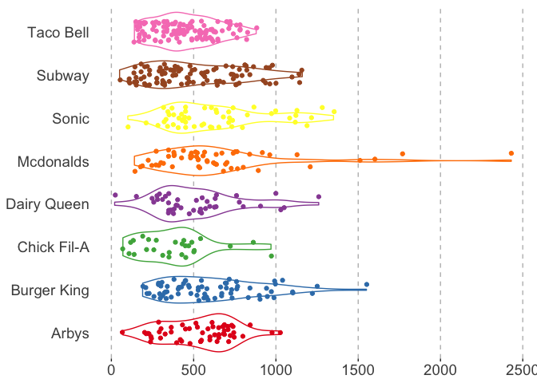

```r
ggplot(data1) +
  geom_violin(aes(restaurant, calories, color = restaurant)) +
  geom_jitter(aes(restaurant, calories, color = restaurant), width= 0.25) +
  coord_flip() +
  theme(legend.position = "none",
    axis.title = element_blank(),
    axis.text = element_text(size = 14),
    axis.ticks.y = element_blank(),
    panel.grid.major.x = element_line(color = 'gray', linetype= 'dashed'),
    panel.background = element_blank()) +
  scale_color_brewer(palette="Set1")
```

Last of all, let’s reorder the y-axis alphabetically & add in a title.

To reorder the title, all we need to do is reverse the order. We can use fct_rev() from the forcats package. The forcats package is included in the tidyverse.

To add the title, we can use ggtitle(). I added a “plot.title = element_text(hjust = 0.5)” in the theme() call to center it.

Now let’s have a look at our final plot!

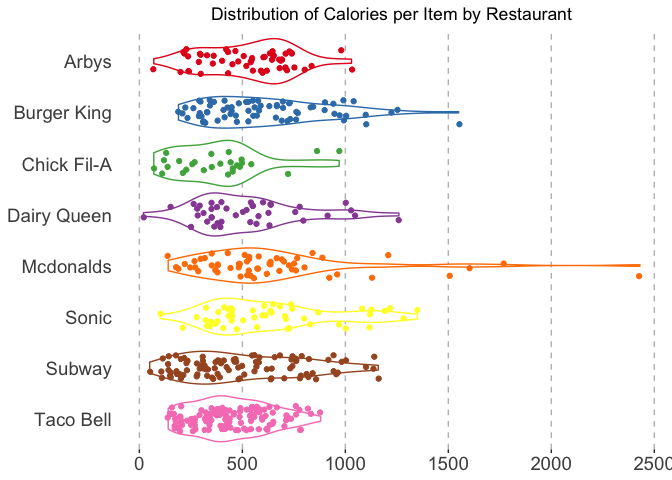

```r
ggplot(data1) +
  geom_violin(aes(fct_rev(restaurant), calories, color = restaurant)) +
  geom_jitter(aes(fct_rev(restaurant), calories, color = restaurant), width= 0.25) +
  coord_flip() +
  theme(legend.position = "none",
    axis.title = element_blank(),
    axis.text = element_text(size = 14),
    axis.ticks.y = element_blank(),
    panel.grid.major.x = element_line(color = 'gray', linetype= 'dashed'),
    panel.background = element_blank(),
    plot.title = element_text(hjust = 0.5)) +
  scale_color_brewer(palette="Set1") +
  ggtitle("Distribution of Calories per Item by Restaurant")
```

Looks great! If you have any questions or comments, feel free to reach out to me on [Twitter](https://twitter.com/sapo83)!